# Lab 8 - fMNIST Classification with Dense Neural Networks (using Tensorflow)

### Fashion-MNIST is a dataset of Zalando's article images—consisting of a training set of 60,000 examples and a test set of 10,000 examples. Each example is a 28x28 grayscale image, associated with a label from 10 classes. This information and data can be retrieved from [fMNIT_Data](https://www.kaggle.com/datasets/zalando-research/fashionmnist)

#### LOAD THE REQUIRED PYTHON LIBRARIES

```python
import numpy as np
import tensorflow as tf
from tensorflow.keras import layers, models
from sklearn.metrics import classification_report
import matplotlib.pyplot as plt
from tensorflow.keras.datasets import fashion_mnist
from keras.callbacks import ModelCheckpoint
from keras.optimizers import Adam
from keras.layers import LeakyReLU
from keras.models import load_model
```

#### STEP 1 LOAD THE fMNIST DATASET

```python
(train_images, train_labels), (test_images, test_labels) = fashion_mnist.load_data()
```

#### STEP 2 EXPLORATORY DATA ANALYSIS

THE CLASSES OF THE DATASET

```python
class_names = ['T-shirt/top', 'Trouser', 'Pullover', 'Dress', 'Coat',
               'Sandal', 'Shirt', 'Sneaker', 'Bag', 'Ankle boot']
print(class_names)
num_classes = len(np.unique(train_labels))
print("Number of classes:", num_classes)
```

```
['T-shirt/top', 'Trouser', 'Pullover', 'Dress', 'Coat', 'Sandal', 'Shirt', 'Sneaker', 'Bag', 'Ankle boot']
Number of classes: 10
```

CHECK THE SHAPE OF THE DATASET

```python
print("Training data shape:", train_images.shape)
print("Training labels shape:", train_labels.shape)
print("Test data shape:", test_images.shape)
print("Test labels shape:", test_labels.shape)
```

```
Training data shape: (60000, 28, 28)
Training labels shape: (60000,)
Test data shape: (10000, 28, 28)
Test labels shape: (10000,)
```

CLASS DISTRIBUTION OF THE DATASET

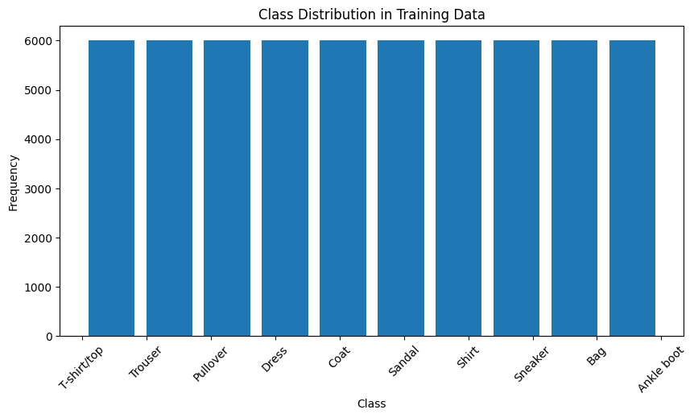

```python
plt.figure(figsize=(10, 5))
plt.hist(train_labels, bins=num_classes, rwidth=0.8)
plt.xticks(range(num_classes), class_names, rotation=45)
plt.title('Class Distribution in Training Data')
plt.xlabel('Class')
plt.ylabel('Frequency')
plt.show()
```

The dataset seems to have a relatively balanced distribution across all classes, which is essential for training a model without bias towards specific classes.

PIE GRAPH SHOWING SAMPLE PERCENTAGE

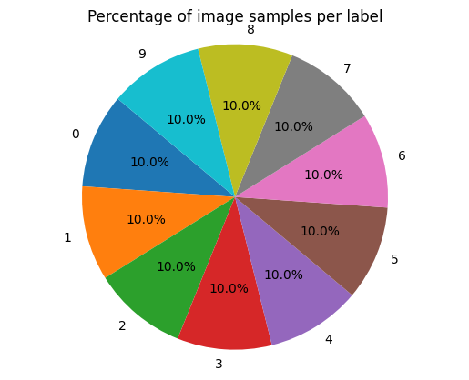

```python
train_labels = np.array(train_labels).flatten().astype(np.int8)
# Count the occurrences of each class
class_counts = np.bincount(train_labels)
# Plot a piechart
plt.pie(class_counts, labels=range(10), autopct='%1.1f%%', startangle=140)
plt.title('Percentage of image samples per label')
plt.axis('equal')
plt.show()
```

DISPLAY THE SAMPLE IMAGE OF EACH CLASS

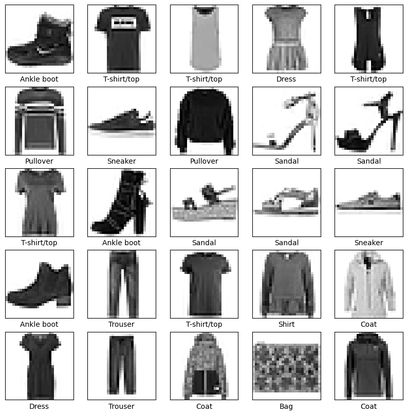

```python
plt.figure(figsize=(10,10))
for i in range(25):
    plt.subplot(5,5,i+1)
    plt.xticks([])
    plt.yticks([])
    plt.grid(False)
    plt.imshow(train_images[i], cmap=plt.cm.binary)
    plt.xlabel(class_names[train_labels[i]])
plt.show()
```

PIXEL VALUE OF AN IMAGE

```python
def visualize_input(i, ax, y):
    img = train_images[i]
    ax.imshow(img, cmap='gray')
    ax.set_title(f"{train_labels[i]}-{class_names[train_labels[i]]}")
    width, height = img.shape
    thresh = img.max()/2.5
    for x in range(width):
        for y in range(height):
            ax.annotate(str(img[x][y]), xy=(y,x),
                        horizontalalignment='center',
                        verticalalignment='center',
                        color='white' if img[x][y]<thresh else 'black')
    ax.set_xticks([])
    ax.set_yticks([])
```

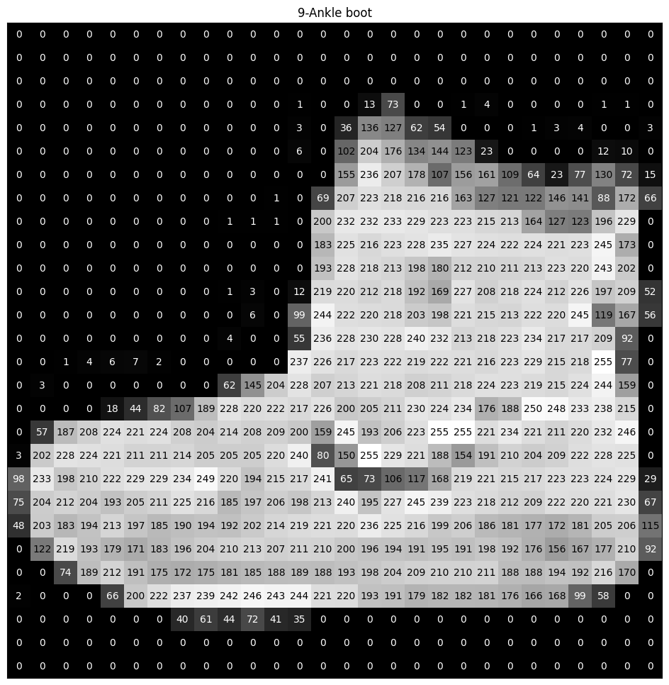

```python
for i in range(1):
    fig = plt.figure(figsize = (12,12))
    ax = fig.add_subplot(111)
    visualize_input(i, ax, train_labels)
```

PIXEL VALUE DISTRIBUTION

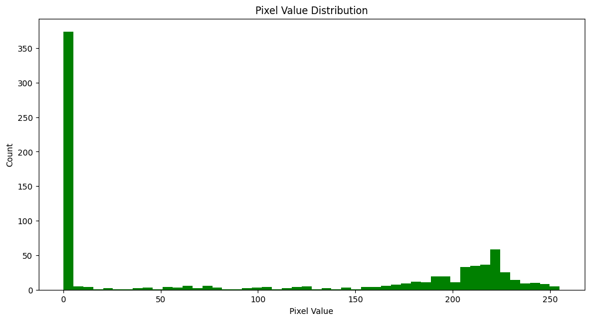

```python
fig = plt.figure(figsize=(12, 6))
plt.hist(train_images[0].flatten(), bins=50, color='green')
plt.title('Pixel Value Distribution')
plt.xlabel('Pixel Value')
plt.ylabel('Count')
plt.show()
```

PIXEL INTENSITY DISTRIBUTION OF EACH SAMPLE

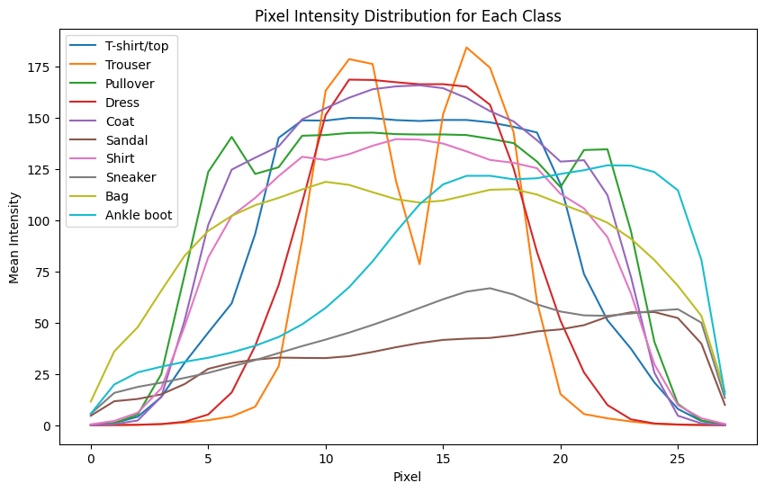

```python
class_pixel_intensity = []
for i in range(10):
    class_indices = np.where(train_labels == i)[0]
    class_images = train_images[class_indices]
    class_mean_intensity = np.mean(class_images, axis=(0, 1))
    class_pixel_intensity.append(class_mean_intensity)
plt.figure(figsize=(10, 6))
for i in range(10):
    plt.plot(class_pixel_intensity[i], label=class_names[i])
plt.title('Pixel Intensity Distribution for Each Class')
plt.xlabel('Pixel')
plt.ylabel('Mean Intensity')
plt.legend()
plt.show()
```

INSIGHTS

1. The dataset contains grayscale images of fashion items.
2. There are 10 classes representing different fashion categories.
3. The class distribution appears to be relatively balanced.
4. Pixel intensity values are distributed between 0 and 255.
5. There are no missing values in the dataset.

#### STEP 3 DEFINE AND TRAIN A FULLY-CONNECTED FEEDFORWARD NEURAL NETWORK

```python
# Normalize pixel values
train_images = train_images / 255.0
test_images = test_images / 255.0

# Define the model
model = models.Sequential([
    layers.Flatten(input_shape=(28, 28)),
    layers.Dense(128, activation='relu'),
    layers.Dense(64, activation='relu'),
    layers.Dense(10, activation='softmax')
])

# Compile the model
model.compile(optimizer='adam',
              loss='sparse_categorical_crossentropy',
              metrics=['accuracy'])

# Train the model
history = model.fit(train_images, train_labels, epochs=10)

# Evaluate the model on the test set
test_loss, test_acc = model.evaluate(test_images, test_labels)
print('Test accuracy:', test_acc)
```

```
Test accuracy: 0.8805999755859375
```

#### STEP 4 EVALUATE THE MODEL USING VALIDATION DATASET

```python
import numpy as np
from sklearn.metrics import classification_report

# Predict class probabilities for the test dataset
test_probabilities = model.predict(test_images)

# Convert probabilities to class labels
test_predictions = np.argmax(test_probabilities, axis=1)

# Evaluate the model using classification report
print("Classification Report:")
print(classification_report(test_labels, test_predictions, target_names=class_names))
```

```
Classification Report:
              precision    recall  f1-score   support

 T-shirt/top       0.76      0.92      0.83      1000
     Trouser       0.98      0.98      0.98      1000
    Pullover       0.76      0.83      0.80      1000
       Dress       0.92      0.87      0.89      1000
        Coat       0.80      0.82      0.81      1000
      Sandal       0.99      0.95      0.97      1000
       Shirt       0.80      0.56      0.66      1000
     Sneaker       0.89      0.98      0.94      1000
         Bag       0.97      0.98      0.97      1000
  Ankle boot       0.97      0.92      0.94      1000

    accuracy                           0.88     10000
   macro avg       0.88      0.88      0.88     10000
weighted avg       0.88      0.88      0.88     10000
```

STEP 5 RUN THE MODEL ON TEST SET

```
Test Accuracy: 0.8806
Precision: 0.8829683545158481
Recall: 0.8806
F1 Score: 0.8784317493069457
```

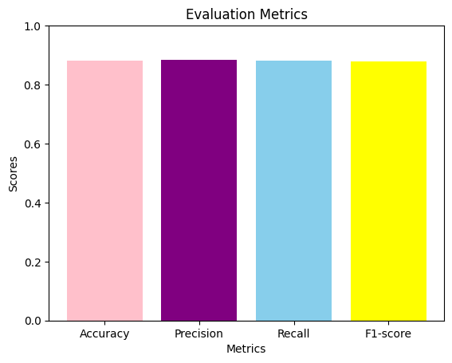

```python
# Make predictions on the test dataset
test_predictions = model.predict(test_images)
test_predictions_classes = np.argmax(test_predictions, axis=1)

# Calculate evaluation metrics
accuracy = accuracy_score(test_labels, test_predictions_classes)
precision = precision_score(test_labels, test_predictions_classes, average='weighted')
recall = recall_score(test_labels, test_predictions_classes, average='weighted')
f1 = f1_score(test_labels, test_predictions_classes, average='weighted')

# Print evaluation metrics
print("Test Accuracy:", accuracy)
print("Precision:", precision)
print("Recall:", recall)
print("F1 Score:", f1)

# Define evaluation metric names and scores
metric_names = ['Accuracy', 'Precision', 'Recall', 'F1-score']
metric_scores = [accuracy, precision, recall, f1]

# Plot the graph
plt.bar(metric_names, metric_scores, color=['pink','purple','skyblue','yellow'])
plt.title('Evaluation Metrics')
plt.xlabel('Metrics')
plt.ylabel('Scores')
plt.ylim(0, 1)
plt.show()
```

The model does well in categorising fashion items, according to the evaluation of the model on the test set. The model's strong test accuracy, precision, recall, and F1 score indicate that it can efficiently generalise to new data and distinguish between various fashion categories.

#### STEP 6 INCREASE PRECISION OF CLASS 5

```python
# Obtain model predictions for the test set
predictions = model.predict(test_images)
predicted_labels = np.argmax(predictions, axis=1)

# Filter indices for class 5
indices_class_5 = np.where(test_labels == 5)[0]
y_test_class_5 = test_labels[indices_class_5]
predicted_labels_class_5 = predicted_labels[indices_class_5]

# Define original threshold
original_threshold = 0.5

# Binarize predictions based on original threshold for class 5
binarized_predictions_class_5_original = (predictions[indices_class_5, 5] >= original_threshold).astype(int)

# Calculate original precision for class 5
true_positives_original = np.sum(binarized_predictions_class_5_original == 1)
total_predicted_positives_original = np.sum(predicted_labels_class_5 == 5)
original_precision_class_5 = true_positives_original / total_predicted_positives_original

# Display original precision for class 5
print("Original Precision for Class 5:", original_precision_class_5)

# Define new threshold to increase precision
new_threshold = 0.9

# Binarize predictions based on new threshold for class 5
binarized_predictions_class_5_new = (predictions[indices_class_5, 5] >= new_threshold).astype(int)

# Calculate adjusted precision for class 5
true_positives_new = np.sum(binarized_predictions_class_5_new == 1)
total_predicted_positives_new = np.sum(binarized_predictions_class_5_new)
adjusted_precision_class_5 = true_positives_new / total_predicted_positives_new

# Display adjusted precision for class 5
print("Adjusted Precision for Class 5 (Threshold at 0.9):", adjusted_precision_class_5)
```

```
Original Precision for Class 5: 1.0
Adjusted Precision for Class 5 (Threshold at 0.9): 1.0
```

#### STEP 7 INCREASE THE RECLL FOR CLASS 5

```python
import numpy as np

# Obtain model predictions for the test set
predictions = model.predict(test_images)
predicted_labels = np.argmax(predictions, axis=1)

# Filter indices for class 5
indices_class_5 = np.where(test_labels == 5)[0]
y_test_class_5 = test_labels[indices_class_5]
predicted_labels_class_5 = predicted_labels[indices_class_5]

# Define original threshold
original_threshold = 0.5

# Binarize predictions based on original threshold for class 5
binarized_predictions_class_5_original = (predictions[indices_class_5, 5] >= original_threshold).astype(int)

# Calculate original recall for class 5
true_positives_original = np.sum(binarized_predictions_class_5_original == 1)
actual_positives_original = np.sum(y_test_class_5 == 5)
original_recall_class_5 = true_positives_original / actual_positives_original

# Display original recall for class 5
print("Original Recall for Class 5:", original_recall_class_5)

# Define new threshold to increase recall
new_threshold = 0.3

# Binarize predictions based on new threshold for class 5
binarized_predictions_class_5_new = (predictions[indices_class_5, 5] >= new_threshold).astype(int)

# Calculate adjusted recall for class 5
true_positives_new = np.sum(binarized_predictions_class_5_new == 1)
adjusted_recall_class_5 = true_positives_new / actual_positives_original

# Display adjusted recall for class 5
print("Adjusted Recall for Class 5 (Threshold at 0.3):", adjusted_recall_class_5)
```

```
Original Recall for Class 5: 0.95
Adjusted Recall for Class 5 (Threshold at 0.3): 0.958
```

CONCLUSION

1. The model's accuracy and recall for class '5' are impacted by changing the threshold. By catching more genuine positives, lowering the threshold can improve recall; but, it may also reduce precision because of an increase in false positives.

#### STEP 8 THREE DIFFERENT NEURAL NETWORKS

MODEL 1

```python
model_1 = models.Sequential([
    layers.Flatten(input_shape=(28, 28)),
    layers.Dense(128, activation='relu'),
    layers.Dense(64, activation='relu'),
    layers.Dense(32, activation='relu'),
    layers.Dense(10, activation='softmax')
])
```

MODEL 2

```python
model_2 = models.Sequential([
    layers.Flatten(input_shape=(28, 28)),
    layers.Dense(256, activation='relu'),
    layers.Dense(128, activation='relu'),
    layers.Dense(64, activation='relu'),
    layers.Dense(10, activation='softmax')
])
```

MODEL 3

```python
model_3 = models.Sequential([
    layers.Flatten(input_shape=(28, 28)),
    layers.Dense(128, activation='sigmoid'),
    layers.Dense(64, activation='sigmoid'),
    layers.Dense(32, activation='sigmoid'),
    layers.Dense(10, activation='softmax')
])
```

TRAIN EACH MODEL

```python
# Compile the models
model_1.compile(optimizer='adam', loss='sparse_categorical_crossentropy', metrics=['accuracy'])
model_2.compile(optimizer='adam', loss='sparse_categorical_crossentropy', metrics=['accuracy'])
model_3.compile(optimizer='adam', loss='sparse_categorical_crossentropy', metrics=['accuracy'])

#TRAIN THE MODELS
history_1 = model_1.fit(train_images, train_labels, epochs=20, validation_data=(test_images, test_labels), verbose=0)
history_2 = model_2.fit(train_images, train_labels, epochs=20, validation_data=(test_images, test_labels), verbose=0)
history_3 = model_3.fit(train_images, train_labels, epochs=20, validation_data=(test_images, test_labels), verbose=0)
```

PLOT TRAINING AND VALIODATION LOSS AND ACCURACY FOR EACH MODEL

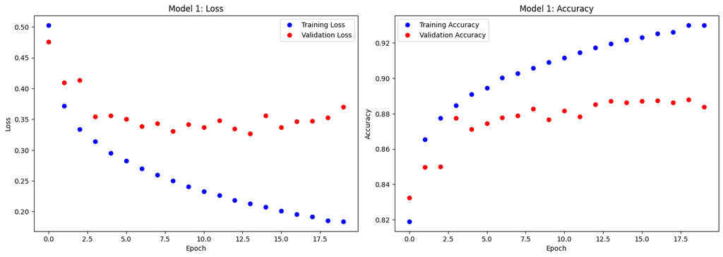

```python
# Model 1
plt.figure(figsize=(15, 15))
plt.subplot(3, 2, 1)
plt.plot(history_1.history['loss'], 'bo', label='Training Loss')
plt.plot(history_1.history['val_loss'], 'ro', label='Validation Loss')
plt.title('Model 1: Loss')
plt.xlabel('Epoch')
plt.ylabel('Loss')
plt.legend()

plt.subplot(3, 2, 2)
plt.plot(history_1.history['accuracy'], 'bo', label='Training Accuracy')
plt.plot(history_1.history['val_accuracy'], 'ro', label='Validation Accuracy')
plt.title('Model 1: Accuracy')
plt.xlabel('Epoch')
plt.ylabel('Accuracy')
plt.legend()

plt.tight_layout()
plt.show()
```

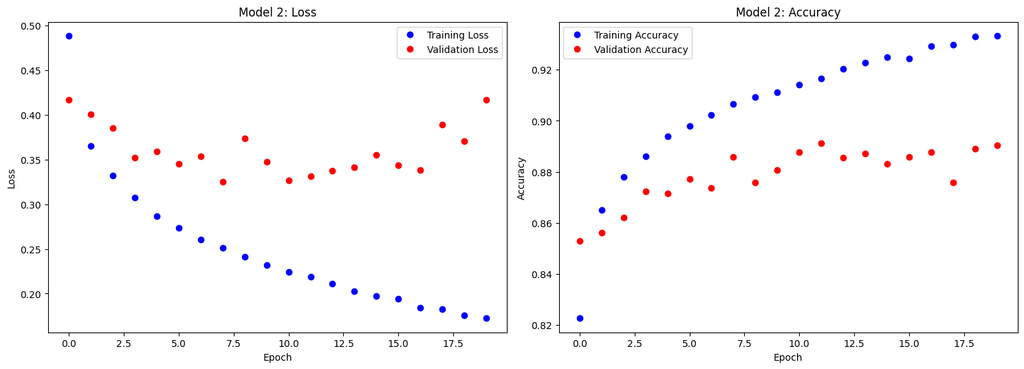

```python
# Model 2
#LOSS
plt.figure(figsize=(15, 15))
plt.subplot(3, 2, 3)
plt.plot(history_2.history['loss'], 'bo', label='Training Loss')
plt.plot(history_2.history['val_loss'], 'ro', label='Validation Loss')
plt.title('Model 2: Loss')
plt.xlabel('Epoch')
plt.ylabel('Loss')
plt.legend()

#ACCURACY
plt.subplot(3, 2, 4)
plt.plot(history_2.history['accuracy'], 'bo', label='Training Accuracy')
plt.plot(history_2.history['val_accuracy'], 'ro', label='Validation Accuracy')
plt.title('Model 2: Accuracy')
plt.xlabel('Epoch')
plt.ylabel('Accuracy')
plt.legend()

plt.tight_layout()
plt.show()
```

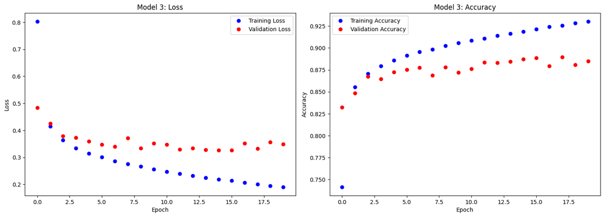

```python
# Model 3
# LOSS
plt.figure(figsize=(15, 15))
plt.subplot(3, 2, 5)
plt.plot(history_3.history['loss'], 'bo', label='Training Loss')
plt.plot(history_3.history['val_loss'], 'ro', label='Validation Loss')
plt.title('Model 3: Loss')
plt.xlabel('Epoch')
plt.ylabel('Loss')
plt.legend()

# ACCURACY
plt.subplot(3, 2, 6)
plt.plot(history_3.history['accuracy'], 'bo', label='Training Accuracy')
plt.plot(history_3.history['val_accuracy'], 'ro', label='Validation Accuracy')
plt.title('Model 3: Accuracy')
plt.xlabel('Epoch')
plt.ylabel('Accuracy')
plt.legend()

plt.tight_layout()
plt.show()
```

```
Test Accuracy: 0.886
Precision: 0.8878558655439672
Recall: 0.886
F1 Score: 0.8862499286745644
```

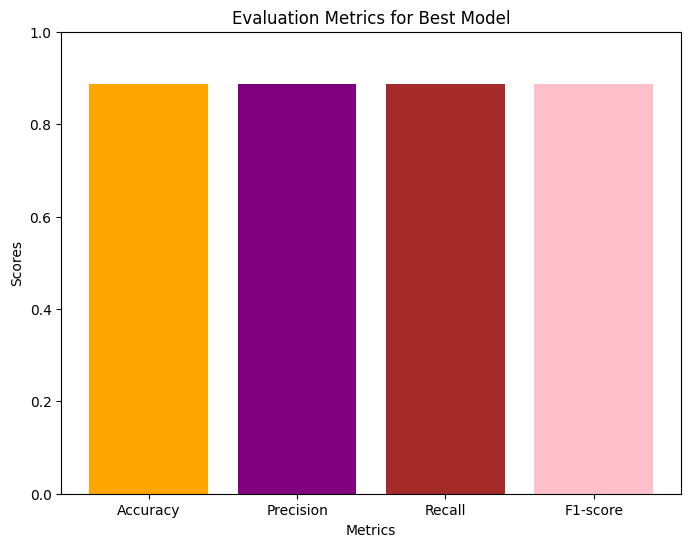

```python
from sklearn.metrics import accuracy_score, precision_score, recall_score, f1_score
# Make predictions on the test dataset
predictions = best_model.predict(test_images)
predicted_labels = np.argmax(predictions, axis=1)

# Calculate evaluation metrics
accuracy = accuracy_score(test_labels, predicted_labels)
precision = precision_score(test_labels, predicted_labels, average='weighted')
recall = recall_score(test_labels, predicted_labels, average='weighted')
f1 = f1_score(test_labels, predicted_labels, average='weighted')

# Print evaluation metrics
print("Test Accuracy:", accuracy)
print("Precision:", precision)
print("Recall:", recall)
print("F1 Score:", f1)

# Define evaluation metric names and scores
metric_names = ['Accuracy', 'Precision', 'Recall', 'F1-score']
metric_scores = [accuracy, precision, recall, f1]

# Plot the evaluation metrics
plt.figure(figsize=(8, 6))
plt.bar(metric_names, metric_scores, color=['orange', 'purple', 'brown', 'pink'])
plt.title('Evaluation Metrics for Best Model')
plt.xlabel('Metrics')
plt.ylabel('Scores')
plt.ylim(0, 1)
plt.show()
```

INSIGHTS:

1. Accuracy: For around 88.6% of the test cases, the model guesses the class labels accurately.
2. Precision is the percentage of successfully predicted positive cases among all positive cases that were forecasted. The model's high degree of prediction precision is indicated by its precision score of 0.8879.
3. Recall: The percentage of accurately anticipated positive cases among all positive occurrences that actually occurred is measured by recall. With a recall score of 0.886, the model successfully accounts for a sizable portion of real positive examples.
4. F1 Score: The F1 score offers a balance between recall and precision by combining the two. The model appears to strike a reasonable balance between recall and precision, as shown by the value of 0.8862.